# Data 602 - Assignment One

Due Friday, September 23, 2022 @ 11:59pm

```r
library(binom)
library(car)
library(collapsibleTree)
library(dbplyr)
library(dplyr)
library(EnvStats)
library(ggformula)
library(ggplot2)
library(gmodels)
library(htmltools)
library(ISLR)
library(knitr)
library(lawstat)
library(markdown)
library(mosaic)
library(mdsr)
library(mosaicData)
library(nycflights13)
library(olsrr)
library(plyr)
library(purrr)
library(plotly)
library(resampledata)
library(rmarkdown)
library(rpart)
library(rpart.plot)
library(rvest)
library(SDaA)
library(shiny)
library(stringi)
library(tibble)
library(tidyr)
library(tidyselect)
library(tinytex)
library(yaml)
library(shiny)
```

Attempt all problems below. You will be required to complete this assignment in R Notebook or R Markdown, and submit then submit a .pdf file (Preview -> Knit to PDF) to the Assignment One in Gradescope.  
Ensure you show all relevant work, either with a series of steps in LaTeX or with R-code/code in R chunks. Use at least four decimal places in your probability computations.

**1.** A recent study[^1] of college graduates in the United states discovered that approximately 60% of degree holders would “change their majors if they could go back to school” and re-do their undergraduate degree. Let’s presume this proportion also holds for Canadian undergraduate university degree holders.

One randomly selects two Canadians who hold an undergraduate degree. Compute the probability that

Compute the probability that

1. both would change their undergraduate major (if they had the ability for a re-do).
2. neither would change their undergraduate major (if they had the ability for a re-do).
3. at least one of the two would change their undergraduate major (if they had the ability for a re-do).
4. Suppose you are to randomly pick $n$-Canadians with undergraduate degrees in such a way that the probability of *at least one of them* would change their undergraduate degree is 0.95. Compute the minimum number of Canadians with undergraduate degrees you would have to randomly select. In other words, compute the *sample size* $n$. (Hint: $ln(a^{b}) = b* ln(a)$…)

```r
#Question 1

pchange = 0.6
pnochange = 0.4
#a
#P(X=2)
pbothchange = dbinom(2,2,pchange)
pbothchange
```

```
[1] 0.36
```

```r
#b
#P(X=0)
pbothnochange = dbinom(0,2,pchange)
pbothnochange
```

```
[1] 0.16
```

```r
#c
#P(X>=1) = 1 - P(X<1) = 1 - P(X=0)
#1 - dbinom(0,2,pchange)
patleastonechange = 1 - pbinom(0,2,pchange)
patleastonechange
```

```
[1] 0.84
```

```r
#d
#with sample size = n
#P(X>=1) = 0.95
#P(X>=1) = 1 - P(X=0)
#P(X=0) = 0.05 = 0.4^n
n = log(0.05)/log(0.4)
n
```

```
[1] 3.269412
```

#### Step 1: Create a series of vectors to hold output

Create an R chunk and type the R code appearing below. You can exclude the documentation.

```r
#nsims = 1000  # the number of simulations
#outcome = numeric(nsims) #create empty vector that will be filled with numeric outcomes
nsims = 3000
outcome = numeric(nsims)
fivesix = numeric(nsims)
```

#### Step 2: Run the Simulation

This step requires that we create a *loop*. There are many types of loops in R, a *while* loop, and a *for* loop. We will be using a for-loop here. Create another R chunk and type the following text (again, you do not need to type the documentation). **ENSURE** the body of the for-loop is wrapped with a open curly bracket $\{$ and a closed curly-bracet $\}$!

```r
for(i in 1:nsims){ #we are going to perform the body of the loop 1000 times
  outcome[i] = sample(c(1,2,3,4,5,6), 1, replace=FALSE)
  fivesix[i] = if (outcome[i] == 5 || outcome[i] == 6) 1 else 0#stores the outcome of the ith toss in position i of outcome
  }  #close the for-loop
simresult = data.frame(outcome) #creates a data frame with two columns
head(simresult,3)  #shows the first three rows of the data frame, outcome of each die toss in column 2
```

|  | outcome |
| --- | --- |
| 1 | 4 |
| 2 | 1 |
| 3 | 5 |

```r
tail(simresult,3)  #shows the last three rows of the data frame, die toss outcome in column 2
```

|  | outcome |
| --- | --- |
| 2998 | 6 |
| 2999 | 5 |
| 3000 | 2 |

```r
fivesixsult = data.frame(fivesix)
head(fivesixsult,5)
```

|  | fivesix |
| --- | --- |
| 1 | 0 |
| 2 | 0 |
| 3 | 1 |
| 4 | 0 |
| 5 | 0 |

```r
NA
```

#### Step 3: Visualize the Simulation with `ggplot2`

You will need the `ggplot2` package for Step 3. Just in case..

```r
library(ggplot2)

sum(simresult$outcome)  #computes the sum of the 1000 tosses appearing in the outcome variable of simresult data frame
```

```
[1] 10635
```

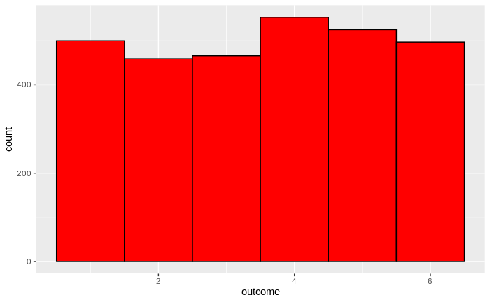

```r
ggplot(data=simresult, aes(x = outcome)) + geom_histogram(binwidth=1, fill='red', col='black') #creates a bar graph of outcomes
```

```r
sum(fivesixsult$fivesix)
```

```
[1] 1022
```

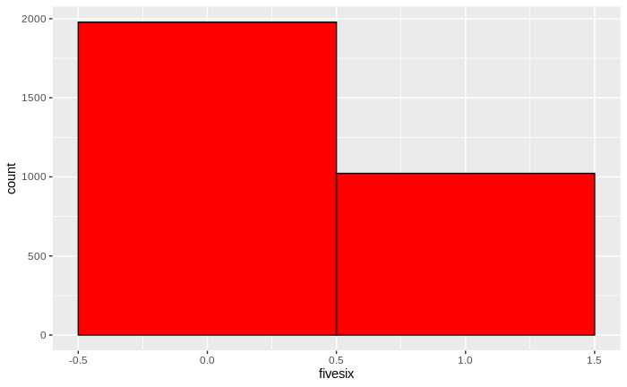

```r
ggplot(data=fivesixsult, aes(x = fivesix)) + geom_histogram(binwidth=1, fill='red', col='black')
```